# Rolling Functions

## Motivation

This chapter covers the implementation of simple rolling functions in C++ and R. The goal is to show the syntax differences between the two languages and compare their performance. These examples were adapted from Vaughan, Hester, and Francois (2024).

## Fair Warning

These functions ignore `NA` values. Adjustments for handling `NA` values will be introduced in the sixth chapter.

R already provides efficient versions of the functions covered here. Code optimizations and improvements will be made in later chapters.

## Load the Package

I loaded the `ece244` package as I added the functions from the next sections to it with the following code:

```r
load_all()
```

## Additional Packages

The following packages are needed for visualizing and simplifying the presentation of the results:

```r
library(bench)
library(ggplot2)
library(dplyr)
library(tidyr)
library(purrr)
library(patchwork)
```

## Cumulative Sum (`cumsum()`)

The next function calculates the cumulative sum of a vector’s elements:

```cpp
[[cpp11::register]] doubles cumsum_cpp_(doubles x) {
  int n = x.size();
  writable::doubles out(n);

  out[0] = x[0];
  for (int i = 1; i < n; ++i) {
    out[i] = out[i - 1] + x[i];
  }
  return out;
}
```

Its R equivalent is:

```r
#' Return the cumulative sum of a vector (R)
#' @param x numeric vector
#' @export
cumsum_r <- function(x) {
  n <- length(x)
  out <- numeric(n)
  out[1] <- x[1]
  for (i in 2:n) {
    out[i] <- out[i - 1] + x[i]
  }
  out
}
```

To document the C++ function, I added the following wrapper to the R code:

```r
#' Return the cumulative sum of a vector (C++)
#' @inheritParams cumsum_r
#' @export
cumsum_cpp <- function(x) {
  cumsum_cpp_(as.double(x))
}
```

To test the functions, I ran the following benchmark code in the R console:

```r
set.seed(123) # for reproducibility
x <- rpois(1e6, lambda = 2) # 1,000,000 elements

cumsum(1:3)
```

```
[1] 1 3 6
```

```r
cumsum_cpp(1:3)
```

```
[1] 1 3 6
```

```r
cumsum_r(1:3)
```

```
[1] 1 3 6
```

```r
mark(
  cumsum(x),
  cumsum_cpp(x),
  cumsum_r(x)
)
```

```
# A tibble: 3 × 6
  expression         min   median `itr/sec` mem_alloc `gc/sec`
  <bch:expr>    <bch:tm> <bch:tm>     <dbl> <bch:byt>    <dbl>
1 cumsum(x)       1.54ms   1.63ms     608.     3.81MB   124.
2 cumsum_cpp(x)  26.55ms  26.95ms      36.7   15.26MB    80.7
3 cumsum_r(x)     46.1ms   46.7ms      21.4    7.66MB     8.01
```

## Cumulative Product (`cumprod()`)

R provides the `cumprod()` function to compute the cumulative product of a vector:

```r
cumprod(1:5)
```

```
[1]   1   2   6  24 120
```

One possible C++ function to implement this is:

```cpp
[[cpp11::register]] doubles cumprod_cpp_(doubles x) {
  int n = x.size();
  writable::doubles out(n);

  out[0] = x[0];
  for (int i = 1; i < n; ++i) {
    out[i] = out[i - 1] * x[i];
  }
  return out;
}
```

Its R equivalent is:

```r
#' Return the cumulative product of a vector (R)
#' @param x numeric vector
#' @export
cumprod_r <- function(x) {
  n <- length(x)
  out <- numeric(n)
  out[1] <- x[1]
  for (i in 2:n) {
    out[i] <- out[i - 1] * x[i]
  }
  out
}
```

To document the C++ function, I added the following wrapper to the R code:

```r
#' Return the cumulative product of a vector (C++)
#' @inheritParams cumprod_r
#' @export
cumprod_cpp <- function(x) {
  cumprod_cpp_(as.double(x))
}
```

To test the functions, I ran the following benchmark code in the R console:

```r
mark(
  cumprod(x),
  cumprod_cpp(x),
  cumprod_r(x)
)
```

```
# A tibble: 3 × 6
  expression          min   median `itr/sec` mem_alloc `gc/sec`
  <bch:expr>     <bch:tm> <bch:tm>     <dbl> <bch:byt>    <dbl>
1 cumprod(x)       1.73ms   2.15ms     309.    15.26MB    233.
2 cumprod_cpp(x)  26.68ms  28.19ms      35.0   15.26MB     28.0
3 cumprod_r(x)    46.44ms   46.7ms      21.4    7.63MB     12.2
```

## Range of Values (`range()`)

A simple example of the `range()` function in R is:

```r
range(x)
```

```
[1]  0 13
```

One possible C++ function to implement this is:

```cpp
[[cpp11::register]] doubles range_cpp_(doubles x) {
  int n = x.size();
  double x1 = x[0], x2 = x[0];

  for (int i = 1; i < n; ++i) {
    x1 = std::min(x1, x[i]);
    x2 = std::max(x2, x[i]);
  }

  writable::doubles out(2);
  out[0] = x1;
  out[1] = x2;

  return out;
}
```

To document the C++ function, I added the following wrapper to the R code:

```r
#' Return the range of values in a vector (C++)
#' @param x numeric vector
#' @export
range_cpp <- function(x) {
  range_cpp_(as.double(x))
}
```

To verify the functions, I ran the following tests and benchmark code in the R console:

```r
range(x)
```

```
[1]  0 13
```

```r
range_cpp(x)
```

```
[1]  0 13
```

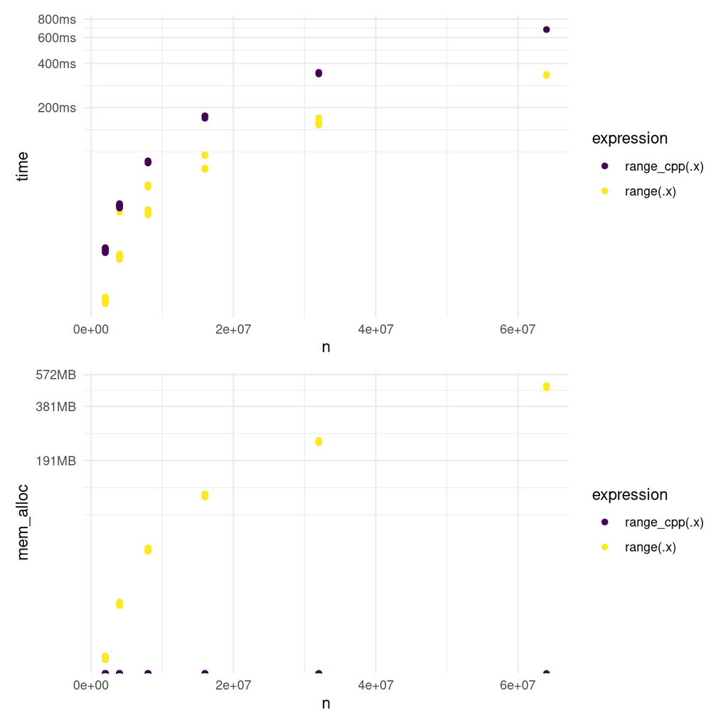

```r
# create random vectors
set.seed(123) # for reproducibility
bigx <- list(
  as.double(rpois(2e6, lambda = 2)),
  as.double(rpois(4e6, lambda = 2)),
  as.double(rpois(8e6, lambda = 2)),
  as.double(rpois(16e6, lambda = 2)),
  as.double(rpois(32e6, lambda = 2)),
  as.double(rpois(64e6, lambda = 2))
)

results <- map(
  bigx,
  ~ mark(
    range(.x),
    range_cpp(.x)
  ) %>%
    mutate(n = length(.x))
)

d <- results %>%
  bind_rows() %>%
  unnest(c(time, mem_alloc, gc, n)) %>%
  select(expression, time, mem_alloc, gc, n)

g1 <- ggplot(d, aes(x = n, y = time, color = expression)) +
  geom_jitter(width = 0.01, height = 0.01) +
  scale_color_viridis_d() +
  theme_minimal()

g2 <- ggplot(d, aes(x = n, y = mem_alloc, color = expression)) +
  geom_jitter(width = 0.01, height = 0.01) +
  scale_color_viridis_d() +
  theme_minimal()

g1 / g2
```

## References

Vaughan, Davis, Jim Hester, and Roman Francois. 2024. “Get Started with Cpp11.” https://cpp11.r-lib.org/articles/cpp11.html#intro.